# Relatório 04

Kaleb Aquino Mileib

01/05/2025

# 1 Objetivo

Neste relatório, deve-se analisar um experimento em DIC (Delineamento Inteiramente Causalizado), realizando a Análise Descritiva geral e de cada tratamento (com média, desvio padrão e coeficiente de variação) e uma análise gráfica de Boxplot. Também é necessário realizar uma Análise de Variância, com hipóteses H0 e H1, tabela de ANAVA, e análise gráfica de resíduos.

# 2 Desenvolvimento

Para trabalhar neste relatório, será necessário utilizar o banco de dados abaixo proposto pelo professor. Com ele, devemos avaliar o **Erro Quadrático Médio (EQM)** dos 5 algorítmos de controle: **PID, LQR, Fuzzy, Controle Adaptativo e por Redes Neurais**. Nele, temos a estrutura de **5 tratamentos** (métodos de controle), **6 repetições** para cada e **1 variável de resposta**.

```r
# Banco de dados
controle <- c(rep("PID", 6), rep("LQR", 6), rep("Fuzzy", 6), rep("Adaptativo", 6), rep("Redes Neurais", 6))
eqm <- c(0.322, 0.338, 0.428, 0.354, 0.356, 0.436,
         0.298, 0.229, 0.253, 0.262, 0.329, 0.294,
         0.444, 0.427, 0.387, 0.527, 0.450, 0.302,
         0.345, 0.286, 0.257, 0.299, 0.259, 0.274,
         0.231, 0.199, 0.275, 0.255, 0.216, 0.288)

dados <- data.frame(controle = as.factor(controle), eqm = eqm)

print(dados)
```

```
##         controle   eqm
## 1            PID 0.322
## 2            PID 0.338
## 3            PID 0.428
## 4            PID 0.354
## 5            PID 0.356
## 6            PID 0.436
## 7            LQR 0.298
## 8            LQR 0.229
## 9            LQR 0.253
## 10           LQR 0.262
## 11           LQR 0.329
## 12           LQR 0.294
## 13         Fuzzy 0.444
## 14         Fuzzy 0.427
```

[output cut: 16 more lines]

## 2.1 Análise Descritiva

Para a realização da Análise Descritiva, foi necessário realizar a média (X barra), o desvio padrão (S) e o coeficiente de variação (CV).

```r
media_geral <- mean(dados$eqm)
dp_geral <- sd(dados$eqm)
cv_geral <- 100 * dp_geral / media_geral

cat("Média:", media_geral, "\nDesvio Padrão:", dp_geral, "\nCoef. de Variação (CV%):", cv_geral)
```

```
## Média: 0.3206667
## Desvio Padrão: 0.0807996
## Coef. de Variação (CV%): 25.19738
```

Conforme é possível ver acima, estes são os valores gerais de média (0.3206667), Desvio Padrão (0.0807996) e Coeficiente de Variação (25.19738).

```r
#por tratamento

library(dplyr)
dados %>%
  group_by(controle) %>%
  summarise(
    media = mean(eqm),
    desvio_padrao = sd(eqm),
    cv = 100 * sd(eqm) / mean(eqm)
  )
```

```
## # A tibble: 5 × 4
##   controle      media desvio_padrao    cv
##   <fct>         <dbl>         <dbl> <dbl>
## 1 Adaptativo    0.287        0.0327  11.4
## 2 Fuzzy         0.423        0.0748  17.7
## 3 LQR           0.278        0.0362  13.0
## 4 PID           0.372        0.0479  12.9
## 5 Redes Neurais 0.244        0.0346  14.2
```

Acima, é possível ver os dados de Média, Desvio Padrão e Coeficiente de Variância para cada controlador. E segue abaixo o gráfico boxplot por tipo de controle, analisando o erro quadrático médio (EQM) de cada um.

Sobre o gráfico, é possível perceber que os métodos de controle Adaptativo e LQR são bem parecidos, quanto à sua distribuição de EQMs, visto que possuem uma mediana relativamente próxima e variações absolutas semelhantes, apesar do LQR possuir maior distância entre seus limites.

Também é possível observar que a distribuição dos valores de EQM dos controles por Fuzzy e PID tendem a um dos limites. No caso do Fuzzy, seus EQMs estão mais distribuidos entre a mediana e o primeiro quartil. Já no PID, o contrário se verifica, onde os valores se distribuem mais entre a mediana e o terceiro quartil.

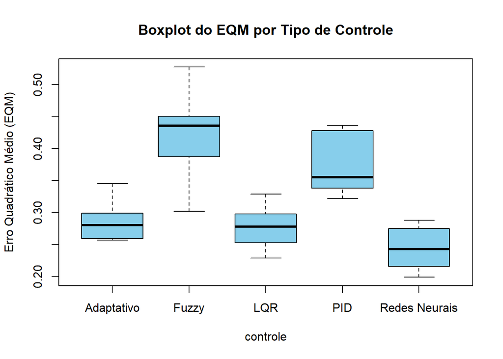

```r
#boxplot

boxplot(eqm ~ controle, data = dados, col = "skyblue",
        main = "Boxplot do EQM por Tipo de Controle",
        ylab = "Erro Quadrático Médio (EQM)")
```

## 2.2 Análise de Variância

Para a Analise de Variância, deve ser estabelecida a relação entre as hipóteses H₀ e H₁, uma tabela ANAVA e uma análise gráfica de resíduos.

Para a relação das hipóteses, segue a explicação abaixo:

**H₀: μ₁ = μ₂ = μ₃ = μ₄ = μ₅ (os controladores têm a mesma média de EQM)**

**H₁: ao menos um controlador difere significativamente**

Abaixo, podemos ver a tabela ANAVA utilizando a função sugerida pelo professor.

```r
modelo <- aov(eqm ~ controle, data = dados)
summary(modelo)
```

```
##             Df Sum Sq Mean Sq F value   Pr(>F)
## controle     4 0.1320 0.03301    14.4 3.16e-06 ***
## Residuals   25 0.0573 0.00229
## ---
## Signif. codes:  0 '***' 0.001 '**' 0.01 '*' 0.05 '.' 0.1 ' ' 1
```

Com isso, podemos interpretar os resultados e afirmar que como o valor P é muito menor que o alpha definido (0,05), a hipótese H0 pode ser descartada, confirmando que existe uma diferença significativa entre os tipos de controle.

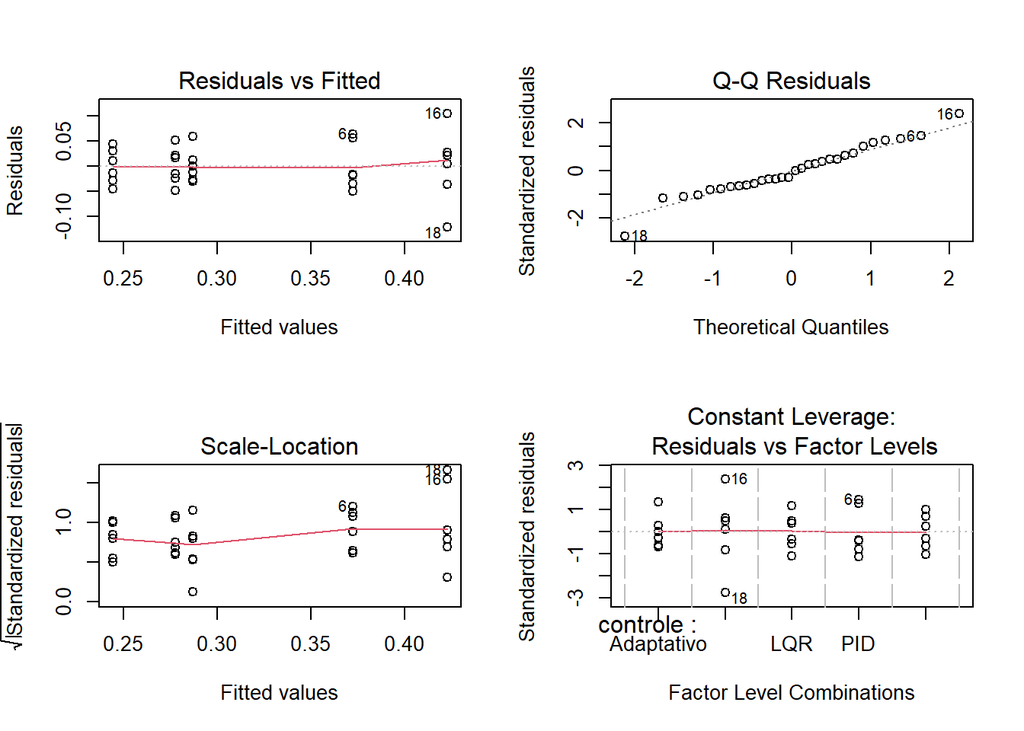

```r
par(mfrow = c(2,2))
plot(modelo)
```

É possível observar que:

Sobre o gráfico *Residuals vs fitted*, é possível perceber que há uma aleatoriedade quanto a distribuição dos resíduos ao longo da linha 0, menos nos últimos valores, que possuem alguns outliers e com uma inclinação na linha de fitted em vermelho.

há uma normalidade da dsitribuição dos resíduos, visto o *Gráfico Q-Q* ser aproximadamente linear, com apenas os dois últimos pontos se destacando, porém nada fora do normal.

O gráfico *Scale Location* apresenta uma homocedasticidade (variância constante) que está, no geral, distribuida de forma aleatória acima e abaixo da linha de regrssão (vermelha), apenas com os primeiros e últimos valores possuindo maior distribuiçãoa baixo da linha.

E por fim, o gráfico *Constant Leverage: Residuals vs Factor Levels* apresenta um tratamento razoavelmente centrado em 0 com uma certa simetria. Portanto, pode-se dizer que os erros estão aleatoriamente distribuidos.

## 2.3 Verificação

Em aula, foi pedido para pesquisar como calcular os Graus de Liberdade (GL), Soma dos Quadrados (SQ) e Quadrado Médio (QM) e comparar com os valores dados pelo R no código abaixo:

```r
# Tabela ANOVA manual
SQT <- sum((tapply(dados$eqm, dados$controle, mean) - mean(dados$eqm))^2 * 6) # 6 repetições
SQR <- sum((dados$eqm - fitted(modelo))^2)
SQTotal <- sum((dados$eqm - mean(dados$eqm))^2)

GLT <- length(unique(dados$controle)) - 1
GLR <- length(dados$eqm) - length(unique(dados$controle))
GLTotal <- length(dados$eqm) - 1

QMT <- SQT / GLT
QMR <- SQR / GLR
QMTotal <- QMT + QMR
F <- QMT / QMR

tabela_anova_manual <- data.frame(
  Fonte = c("Tratamento", "Resíduo", "Total"),
  GL = c(GLT, GLR, GLTotal),
  SQ = c(SQT, SQR, SQTotal),
  QM = c(QMT, QMR, QMTotal),
  F = c(F, NA, NA)
)
tabela_anova_manual
```

```
##        Fonte GL        SQ         QM        F
## 1 Tratamento  4 0.1320277 0.03300692 14.40067
## 2    Resíduo 25 0.0573010 0.00229204       NA
## 3      Total 29 0.1893287 0.03529896       NA
```

Portanto, os GL representam a quantidade de informações independentes disponíveis para variarem. O **GL dos tratamentos (GLT)** é feito pelo N° de tratamentos - 1, sendo GLT = 4. O **GL dos resíduos (GLR)** é o N° de observações - N° de tratamentos, que é GLR = 25. O total é a soma dos dois. Comparando com a tabela, os valores indicados pelo R são verdadeiros.

Sobre a SQ, que significa a variabilidade associada a cada fonte. Ao dividir em dois grupos, **SQ dos Tratamentos (SQT)** e **SQ dos Resíduos (SQR)**, deve-se para o primeiro, calcular a média de cada grupo, subtrair a média geral, elevar ao quadrado e multiplicar pelo número de repetições (6 por grupo), resultando em SQT = 0,132028. Para o segundo, deve-se calcular a diferença entre o valor observado e o valor ajustado e elevar ao quadrado. O resultado é SQR = 0,057301. O total é a soma de ambos. Comparando com a tabela, os valores coincidem.

O Quadrado Médio (QM) é feito pelo cálculo da SQ dividida pelo respectivo GL, representando a variabilidade média. Temos o **Quadrado Médio dos Tratamentos (QMT)** sendo a divisão entre GLT e SQT, resultando em QMT = 0,033007. E temos o **Quadrado Médio dos Resíduos (QMR)** representado pela divisão entre GLR e SQR, com QMR = 0,002292. O total pode ser representado pela soma dos dois, sendo QMTotal = 0,035299. Os resultados coincidem com a tabela.

# 3 Conclusão

A partir da análise realizada neste relatório, foi possível avaliar e comparar o desempenho de cinco algoritmos de controle (PID, LQR, Fuzzy, Adaptativo e Redes Neurais) quanto ao Erro Quadrático Médio (EQM), utilizando um experimento em Delineamento Inteiramente Casualizado (DIC). A análise descritiva inicial, composta pela média, desvio padrão e coeficiente de variação, forneceu uma visão geral e individual de cada tratamento, permitindo identificar diferenças preliminares nos comportamentos dos métodos de controle avaliados.

O gráfico boxplot complementou a análise descritiva, evidenciando a distribuição dos EQMs em cada tipo de controle. Observou-se que os métodos Adaptativo e LQR apresentaram padrões similares em suas distribuições, enquanto os métodos Fuzzy e PID demonstraram assimetrias distintas, sugerindo variações de desempenho mais específicas nesses algoritmos.

A Análise de Variância (ANOVA) confirmou estatisticamente que há diferença significativa entre os métodos de controle analisados, com valor-p muito inferior ao nível de significância adotado (α = 0,05). Isso indica a rejeição da hipótese nula (H₀), que assumia igualdade entre as médias dos tratamentos, reforçando a conclusão de que ao menos um dos controladores se destaca em relação aos demais.

A análise dos resíduos mostrou que os pressupostos da ANOVA foram razoavelmente atendidos: os resíduos apresentaram distribuição aproximadamente normal, homocedasticidade e ausência de padrões sistemáticos, apesar da presença de alguns valores atípicos. Esses aspectos garantem a confiabilidade dos resultados inferenciais obtidos.

Por fim, a verificação manual dos componentes da ANOVA — graus de liberdade (GL), soma dos quadrados (SQ), quadrado médio (QM) e estatística F — confirmou a consistência dos cálculos realizados pelo R, reforçando a compreensão prática dos conceitos estatísticos envolvidos.

Dessa forma, o experimento permitiu não apenas identificar diferenças significativas entre os métodos de controle, como também consolidar o uso das ferramentas estatísticas para análise de experimentos em DIC, sendo um recurso valioso na comparação de desempenho entre diferentes técnicas.

Sites utilizados de referência para os estudos: https://fernandafperes.com.br/blog/interpretacao-boxplot/ https://rpubs.com/iabrady/residual-analysis